# CHDH SNA 5

[Johan Koskinen](https://psychologicalsciences.unimelb.edu.au/research/msps-research-groups/Social_Networks_Laboratory)

2025-02-27

# Overview

- Different types of data
- Imperfect data

Load packages

```r
library("sna")
library("network")
library('RSiena')
```

# Two-mode data

Consider boards $i=1,\ldots,m$ and directors $j=1,\ldots,m$, and let
$$\begin{equation*}
X_{ij}= \left\{
\begin{array}{lr}
1,&\text{if board } i \text{ has as a board member director }
j\\
0,&\text{else}
\end{array}
\right.
\end{equation*}$$

## Data

A subset of the data on Swedish interlocking directors used in Koskinen and Edling (2012)

```r
SWE.b.t1 <- as.matrix(read.table("https://raw.githubusercontent.com/johankoskinen/CHDH-SNA/main/data/SWE-Borard-t1.txt"))

SWE.b.t2 <- as.matrix(read.table("https://raw.githubusercontent.com/johankoskinen/CHDH-SNA/main/data/SWE-Borard-t2.txt"))
```

Find out number of nodes in nodesets:

```r
nrsend <- dim( SWE.b.t1 )[1]
nrrec <- dim( SWE.b.t1 )[2]
```

To create bipartite network objects you need two node sets and must create the node sets too

```r
senders <- sienaNodeSet(nrsend, nodeSetName="senders")
receivers <- sienaNodeSet(nrrec, nodeSetName="receivers")
```

Define the dependent variable:

```r
myBipNet <- sienaDependent(array(c( SWE.b.t1,SWE.b.t2), dim=c(nrsend,nrrec,2)),# not square!
                      "bipartite",# this is the type (as opposed to one-mode)
                      nodeSet=c("senders","receivers")# associate rows and columns with nodesets
                      )
```

At this point we do not have any other variables:

```r
bipData <- sienaDataCreate(myBipNet,nodeSets=list(senders,receivers))
```

### What effects?

Get effects table for model specification:

```r
bipEffects <- getEffects(bipData)
```

### Descriptives

Generate initial descriptive output file:

```r
print01Report(bipData,modelname="bip1")
```

> We should really always look at the print-report

#### Four-cycles

```r
bipEffects <- includeEffects(bipEffects,cycle4,name="myBipNet")
```

```
##   effectName   shortName include fix   test  initialValue parm
## 1 4 cycles (#) cycle4    TRUE    FALSE FALSE          0   1
```

#### Possible effects

```r
 bipEffects <- includeEffects(bipEffects,outActSqrt)
```

```
##   effectName                  shortName  include fix   test  initialValue parm
## 1 outdegree - activity (sqrt) outActSqrt TRUE    FALSE FALSE          0   0
```

```r
# Bypass bug related to initial values for bipartite network rates:
# bipEffects <- setEffect(bipEffects,Rate,name="leisure",initialValue=1.0,period=1,type="rate")
```

## Algorthm

```r
bip.algo <- sienaAlgorithmCreate( projname = 'bip.mod' )
```

Estimate!

```r
bip.mod.ans <- siena07( bip.algo,
                         data = bipData ,
                         effects =bipEffects ,
                         batch = TRUE,
                         returnDeps = TRUE )
```

## Results

Check estimation results

```r
bip.mod.ans
```

```
## Estimates, standard errors and convergence t-ratios
##
##                                       Estimate   Standard   Convergence
##                                                    Error      t-ratio
##
## Rate parameters:
##   0       Rate parameter               1.9298  ( 0.1468   )
##
## Other parameters:
##   1. eval outdegree (density)         -2.0150  ( 0.7598   )   -0.0257
##   2. eval 4 cycles (1)                 0.3939  ( 0.0766   )    0.0097
##   3. eval outdegree - activity (sqrt) -0.1665  ( 0.1910   )   -0.0228
##
## Overall maximum convergence ratio:    0.0320
##
##
## Total of 2294 iteration steps.
```

## GOF

```r
(gofi0 <- sienaGOF(bip.mod.ans, IndegreeDistribution, verbose=TRUE, join=TRUE,
     varName="myBipNet"))
```

```
## Detected 1000 iterations and 1 group.
```

```
## Calculating auxiliary statistics for period  1 .
```

```
##   Period 1
```

[output not shown]

```
## Siena Goodness of Fit ( IndegreeDistribution ), all periods
## =====
## Monte Carlo Mahalanobis distance test p-value:  0.037
## -----
## One tailed test used  (i.e. estimated probability of greater distance than observation).
## -----
## Calculated joint MHD = ( 18.43 ) for current model.
```

```r
(gofo0 <- sienaGOF(bip.mod.ans, OutdegreeDistribution, verbose=TRUE, join=TRUE,
     varName="myBipNet"))
```

```
## Detected 1000 iterations and 1 group.
```

```
## Calculating auxiliary statistics for period  1 .
```

```
##   Period 1
```

[output not shown]

```
## Siena Goodness of Fit ( OutdegreeDistribution ), all periods
## =====
## Monte Carlo Mahalanobis distance test p-value:  0.158
## -----
## One tailed test used  (i.e. estimated probability of greater distance than observation).
## -----
## Calculated joint MHD = ( 13.11 ) for current model.
```

Note now that the indegree
$$\sum_i x_{ij}$$
will be, for each director $j$, the number of boards that choose director $j$

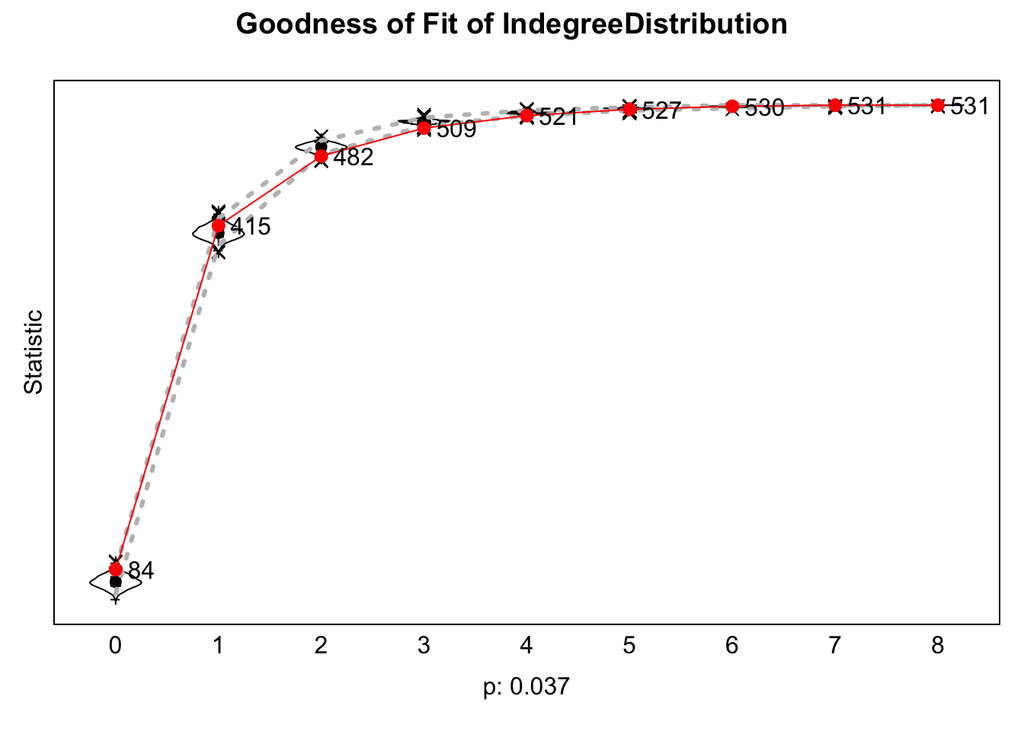

```r
plot(gofi0)
```

The outdegree
$$\sum_j x_{ij}$$
will be, for each board $i$, the number of directors the board has

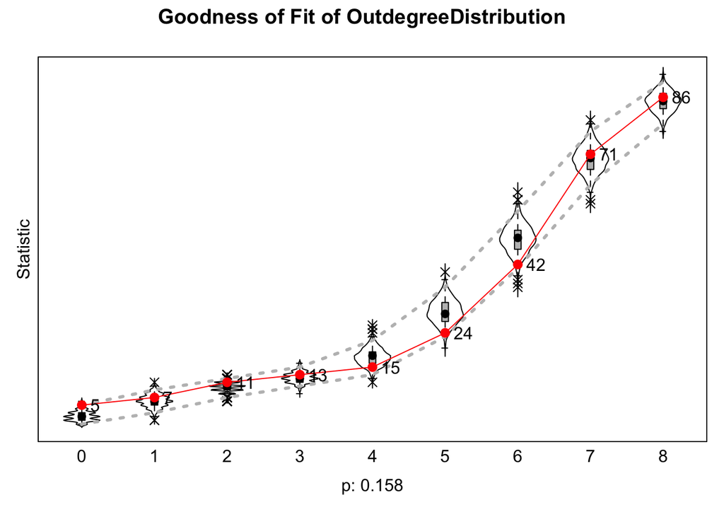

```r
plot(gofo0)
```

> This simple model actually does relatively OK in terms of not creating boards that have too many or too few directors!

There is no simple way (to the best of my knowledge) of restricting the degree distribution. You may set the maximum using `MaxDegree=c(myBipNet=15)` in `sienaAlgorithmCreate`. There are some relevant effects as well.

# One-mode & two-mode

Consider now the Glasgow dataset and assume that we will model friendship $X$ alongside
$$\begin{equation*}
z_{ij}^{(r)}= \left\{
\begin{array}{lr}
1,&\text{if pupil } i \text{ engages in category } j \text{ of
activity } r\\
0,&\text{else}
\end{array}
\right.
\end{equation*}$$
for a number $r=1,\ldots,R$ different activities. The activities will be

- Leisure activities
- Music genres
- Different drugs

```r
temp <- tempfile()
download.file("http://www.stats.ox.ac.uk/~snijders/siena/Glasgow_bip_data.zip",temp)

# read the friendship data:
friendship1 <- as.matrix(read.table(unz(temp,"Glasgow-1-net.dat")))
friendship2 <- as.matrix(read.table(unz(temp,"Glasgow-2-net.dat")))

# now demographic info:
demographics <- as.matrix(read.table(unz(temp,"Glasgow-sex-birthyear.dat")))

# now the bipartite data:
leisure1 <- as.matrix(read.table(unz(temp,"GL-1-lsr.dat")))
leisure2 <- as.matrix(read.table(unz(temp,"GL-2-lsr.dat")))
music1 <- as.matrix(read.table(unz(temp,"GL-1-mus.dat")))
music2 <- as.matrix(read.table(unz(temp,"GL-2-mus.dat")))
drugs1 <- as.matrix(read.table(unz(temp,"GL-1-drg.dat")))
drugs2 <- as.matrix(read.table(unz(temp,"GL-2-drg.dat")))

unlink(temp)
```

### Recoding

Recode the behaviours into meaningful affiliation info:

```r
leisure1[leisure1 %in% c(2,3,4)] <- 0
# leisure1[leisure1 == 2] <- 1
leisure2[leisure2 %in% c(2,3,4)] <- 0
# leisure2[leisure2 == 2] <- 1
drugs1[drugs1 %in% c(1)] <- 0
drugs1[drugs1 %in% c(2,3,4)] <- 1
drugs2[drugs2 %in% c(1)] <- 0
drugs2[drugs2 %in% c(2,3,4)] <- 1
```

Recode valued friendship data & identify missings:

```r
friendship1[friendship1 == 2] <- 1
friendship1[friendship1 == 9] <- NA
friendship2[friendship2 == 2] <- 1
friendship2[friendship2 == 9] <- NA
```

We need to find out the number of nodes in different nodesets as well as the number of items in different scales:

```r
(nrpupils <- dim(leisure1)[1])
```

```
## [1] 160
```

```r
(nrleisureItems <- dim(leisure1)[2])
```

```
## [1] 15
```

```r
(nrmusicItems <- dim(music1)[2])
```

```
## [1] 16
```

```r
(nrdrugsItems <- dim(drugs1)[2])
```

```
## [1] 14
```

## Node sets

We now have 4 different node sets. Define the different node sets for R:

```r
pupils <- sienaNodeSet(nrpupils, nodeSetName="pupils")
leisureItems <- sienaNodeSet(nrleisureItems, nodeSetName="leisureItems")
musicItems <- sienaNodeSet(nrmusicItems, nodeSetName="musicItems")
drugsItems <- sienaNodeSet(nrdrugsItems, nodeSetName="drugsItems")
```

## Dependent variables

We will format each affiliation network as a dependent variable

```r
leisure <- sienaDependent(array(c(leisure1, leisure2),
                dim=c(nrpupils, nrleisureItems,2)),
                "bipartite", nodeSet=c("pupils", "leisureItems"))
music <- sienaDependent(array(c(music1, music2),
                dim=c(nrpupils, nrmusicItems,2)),
                "bipartite", nodeSet=c("pupils", "musicItems"))
drugs <- sienaDependent(array(c(drugs1, drugs2),
                dim=c(nrpupils, nrdrugsItems,2)),
                "bipartite", nodeSet=c("pupils", "drugsItems"))
```

in addition to the dependent one-mode friendship network

```r
friendship <- sienaDependent(array(c(friendship1, friendship2),
                dim=c(nrpupils, nrpupils,2)), nodeSet="pupils")
```

## Covariate

Different node sets may have different covariates. Here we only use the sex of the pupils:

```r
sex.F <- coCovar(demographics[, 1], nodeSet="pupils")
```

## Data create

We have now defined all of the different variables and can combine them in an RSiena dataset

```r
bipData <- sienaDataCreate(friendship,# one-mode network
                           leisure, # pupil affiliation with leisure activity
                           music, # pupil affiliation with different music styles
                           drugs, # pupil affiliation with different drugs
                           sex.F, # sex (male/female; 0/1)
                           nodeSets=list(pupils, leisureItems, musicItems, drugsItems)# the different node sets
                           )
```

## Effects

Get effects table for model specification:

```r
bipEffects <- getEffects(bipData)
```

## Descriptives

Generate initial descriptive outputfile:

```r
print01Report(bipData, modelname="Bipartite-illustration")
```

Look at the generated output file “Bipartite-illustration.out” to see how RSiena interpreted the directives provided and to get an impression of the data (eyeball the degrees, look at occurrence of missings, look at Jaccard indices).

## Specify the model

When we specify the effects to include, pay special attention to the `name` variable

```r
bipEffects <- includeEffects(bipEffects, transTrip, name="friendship")
```

```
##   effectName                      shortName include fix   test  initialValue
## 1 friendship: transitive triplets transTrip TRUE    FALSE FALSE          0
##   parm
## 1 0
```

```r
bipEffects <- includeEffects(bipEffects, from, name="friendship",
                            interaction1="leisure")
```

```
##   effectName                         shortName include fix   test  initialValue
## 1 friendship: from leisure agreement from      TRUE    FALSE FALSE          0
##   parm
## 1 0
```

```r
bipEffects <- includeEffects(bipEffects, from, name="friendship",
                            interaction1="music")
```

```
##   effectName                       shortName include fix   test  initialValue
## 1 friendship: from music agreement from      TRUE    FALSE FALSE          0
##   parm
## 1 0
```

```r
bipEffects <- includeEffects(bipEffects, from, name="friendship",
                            interaction1="drugs")
```

```
##   effectName                       shortName include fix   test  initialValue
## 1 friendship: from drugs agreement from      TRUE    FALSE FALSE          0
##   parm
## 1 0
```

```r
bipEffects <- includeEffects(bipEffects, cycle4, name="leisure")
```

```
##   effectName            shortName include fix   test  initialValue parm
## 1 leisure: 4 cycles (#) cycle4    TRUE    FALSE FALSE          0   1
```

```r
bipEffects <- includeEffects(bipEffects, cycle4, name="music")
```

```
##   effectName          shortName include fix   test  initialValue parm
## 1 music: 4 cycles (#) cycle4    TRUE    FALSE FALSE          0   1
```

```r
bipEffects <- includeEffects(bipEffects, cycle4, name="drugs")
```

```
##   effectName          shortName include fix   test  initialValue parm
## 1 drugs: 4 cycles (#) cycle4    TRUE    FALSE FALSE          0   1
```

```r
bipEffects <- includeEffects(bipEffects, to, name="leisure",
                             interaction1="friendship")
```

```
##   effectName                       shortName include fix   test  initialValue
## 1 leisure: friendship to agreement to        TRUE    FALSE FALSE          0
##   parm
## 1 0
```

```r
bipEffects <- includeEffects(bipEffects, to, name="music",
                             interaction1="friendship")
```

```
##   effectName                     shortName include fix   test  initialValue
## 1 music: friendship to agreement to        TRUE    FALSE FALSE          0
##   parm
## 1 0
```

```r
bipEffects <- includeEffects(bipEffects, to, name="drugs",
                             interaction1="friendship")
```

```
##   effectName                     shortName include fix   test  initialValue
## 1 drugs: friendship to agreement to        TRUE    FALSE FALSE          0
##   parm
## 1 0
```

```r
bipEffects
```

```
##    name       effectName                         include fix   test
## 1  friendship basic rate parameter friendship    TRUE    FALSE FALSE
## 2  friendship friendship: outdegree (density)    TRUE    FALSE FALSE
## 3  friendship friendship: reciprocity            TRUE    FALSE FALSE
## 4  friendship friendship: transitive triplets    TRUE    FALSE FALSE
## 5  friendship friendship: from leisure agreement TRUE    FALSE FALSE
## 6  friendship friendship: from music agreement   TRUE    FALSE FALSE
## 7  friendship friendship: from drugs agreement   TRUE    FALSE FALSE
## 8  leisure    basic rate parameter leisure       TRUE    FALSE FALSE
## 9  leisure    leisure: outdegree (density)       TRUE    FALSE FALSE
## 10 leisure    leisure: 4 cycles (#)              TRUE    FALSE FALSE
## 11 leisure    leisure: friendship to agreement   TRUE    FALSE FALSE
## 12 music      basic rate parameter music         TRUE    FALSE FALSE
## 13 music      music: outdegree (density)         TRUE    FALSE FALSE
## 14 music      music: 4 cycles (#)                TRUE    FALSE FALSE
```

[output cut: 25 more lines]

## Algorithm

Create algorithm object:

```r
bipModel <- sienaAlgorithmCreate(projname='bipartite-Glasgow-results')
```

```
## If you use this algorithm object, siena07 will create/use an output file bipartite-Glasgow-results.txt .
```

**Estimate**!

```r
bipResults <- siena07(bipModel,
                      data=bipData,
                      effects=bipEffects,
                      batch = TRUE,
                      returnDeps = TRUE)
```

[output not shown]

[output cut: 63 more lines]

[output not shown]

```r
bipResults
```

```
## Estimates, standard errors and convergence t-ratios
##
##                                               Estimate   Standard   Convergence
##                                                            Error      t-ratio
##    1. rate basic rate parameter friendship    12.2009  ( 0.9904   )    0.0428
##    2. eval friendship: outdegree (density)    -2.7331  ( 0.0972   )    0.0144
##    3. eval friendship: reciprocity             2.0573  ( 0.1269   )    0.0546
##    4. eval friendship: transitive triplets     0.3378  ( 0.0312   )    0.0406
##    5. eval friendship: from leisure agreement  0.0633  ( 0.0400   )    0.0011
##    6. eval friendship: from music agreement    0.0480  ( 0.0375   )   -0.0013
##    7. eval friendship: from drugs agreement   -0.1262  ( 0.1147   )   -0.0096
##    8. rate basic rate parameter leisure        4.3669  ( 0.3090   )   -0.0732
##    9. eval leisure: outdegree (density)       -1.8063  ( 0.1048   )    0.0882
##   10. eval leisure: 4 cycles (1)               0.0073  ( 0.0011   )    0.0987
##   11. eval leisure: friendship to agreement    0.3123  ( 0.0597   )    0.1086
##   12. rate basic rate parameter music          5.0734  ( 0.4059   )    0.0556
##   13. eval music: outdegree (density)         -1.7326  ( 0.0931   )   -0.0404
##   14. eval music: 4 cycles (1)                 0.0078  ( 0.0010   )   -0.0188
##   15. eval music: friendship to agreement      0.2764  ( 0.0503   )   -0.0288
##   16. rate basic rate parameter drugs          2.4790  ( 0.3532   )    0.1876
##   17. eval drugs: outdegree (density)         -3.5884  ( 0.3398   )    0.1818
##   18. eval drugs: 4 cycles (1)                 0.1708  ( 0.0339   )    0.1686
##   19. eval drugs: friendship to agreement      1.2036  ( 0.2505   )    0.1998
##
## Overall maximum convergence ratio:    0.2925
##
##
## Total of 3550 iteration steps.
```

## Results

Perhaps convergence is not satisfactory yet, so the model might be restimated in a further step:

```r
bipResults <- siena07(bipModel, data=bipData, effects=bipEffects,
                            prevAns=bipResults,batch = TRUE, returnDeps=TRUE)
```

[output not shown]

[output cut: 34 more lines]

[output not shown]

```r
bipResults
```

```
## Estimates, standard errors and convergence t-ratios
##
##                                               Estimate   Standard   Convergence
##                                                            Error      t-ratio
##    1. rate basic rate parameter friendship    12.1705  ( 0.9163   )    0.0319
##    2. eval friendship: outdegree (density)    -2.7401  ( 0.1074   )    0.0842
##    3. eval friendship: reciprocity             2.0563  ( 0.1240   )    0.0779
##    4. eval friendship: transitive triplets     0.3360  ( 0.0337   )    0.0172
##    5. eval friendship: from leisure agreement  0.0658  ( 0.0384   )    0.0751
##    6. eval friendship: from music agreement    0.0501  ( 0.0438   )    0.0927
##    7. eval friendship: from drugs agreement   -0.1271  ( 0.1338   )    0.0352
##    8. rate basic rate parameter leisure        4.3804  ( 0.3483   )   -0.0496
##    9. eval leisure: outdegree (density)       -1.8053  ( 0.1065   )    0.0486
##   10. eval leisure: 4 cycles (1)               0.0073  ( 0.0011   )    0.0543
##   11. eval leisure: friendship to agreement    0.3098  ( 0.0662   )    0.0547
##   12. rate basic rate parameter music          5.0737  ( 0.3596   )    0.0096
##   13. eval music: outdegree (density)         -1.7294  ( 0.0843   )    0.0077
##   14. eval music: 4 cycles (1)                 0.0077  ( 0.0010   )   -0.0006
##   15. eval music: friendship to agreement      0.2786  ( 0.0467   )   -0.0072
##   16. rate basic rate parameter drugs          2.4541  ( 0.4380   )   -0.0181
##   17. eval drugs: outdegree (density)         -3.5700  ( 0.3521   )   -0.0282
##   18. eval drugs: 4 cycles (1)                 0.1666  ( 0.0408   )   -0.0159
##   19. eval drugs: friendship to agreement      1.1872  ( 0.2264   )   -0.0310
##
## Overall maximum convergence ratio:    0.1464
##
##
## Total of 3471 iteration steps.
```

# Multigroup analysis

A brief example of the data structure for running Bayesian hierarchical SAOMs. This requires the beta package `multiSiena` (used to be in `RSienaTest`). Best way is to download from https://www.stats.ox.ac.uk/~snijders/siena/multiSiena_1.2.20.tar.gz (Mac) and <Download binary multiSiena_1.2.20.zip for installation under Windows> (PC), and then installing this from the Packages menue in RStudio.

```r
library(multiSiena)
```

## Data

We use a subset of a large dataset (Knecht, A., 2008. Friendship Selection and Friends’ Influence Dynamics of Networks and Actor Attributes in Early Adolescence.’)

```r
load(url("http://www.stats.ox.ac.uk/~snijders/siena/G21.RData"))
```

The main data are

```r
TwentyOne_Groups
```

```
## Dependent variables:
## friends : oneMode
##  delinq : behavior
## Total number of groups: 21
## Total number of periods: 21
## Changing covariates:  adv, sex, nn
## Changing dyadic covariates:  oldties
```

```r
class(TwentyOne_Groups)
```

```
## [1] "sienaGroup" "siena"
```

```r
length(TwentyOne_Groups)
```

```
## [1] 21
```

This is a sienaGroup object, created by

```r
?sienaGroupCreate
```

The groups are the elements of `TwentyOne_Groups`. The first group is

```r
TwentyOne_Groups[[1]]
```

```
## Dependent variables:  friends, delinq
## Number of observations: 2
##
## Nodeset                  Actors
## Number of nodes              21
##
## Dependent variable friends
## Type               oneMode
## Observations       2
## Nodeset            Actors
## Densities          0.24 0.22
##
## Dependent variable delinq
## Type               behavior
## Observations       2
## Nodeset            Actors
## Range              0 - 4
##
## Changing covariates:  adv, sex, nn
## Changing dyadic covariates:  oldties
```

There is a group-level covariate `nn` that is `log(group size - 1)`

```r
group_n <- sapply(TwentyOne_Groups, function(x){length(x$nodeSets[[1]])})
group_n
```

```
##  Data1  Data2  Data3  Data4  Data5  Data6  Data7  Data8  Data9 Data10 Data11
##     21     28     27     30     27     25     28     28     24     26     26
## Data12 Data13 Data14 Data15 Data16 Data17 Data18 Data19 Data20 Data21
##     23     29     27     26     26     33     27     28     13     22
```

## Print report

To further understand data, get the initial description

```r
print01Report(TwentyOne_Groups, modelname = 'Andrea_21Groups')
```

## Further material

Examples of how to specify a model for this multigroup object is provided at https://www.stats.ox.ac.uk/~snijders/siena/RscriptsienaBayes.r